# Biostat M280 Homework 3

Due Mar 1 @ 11:59PM

Use tidyverse and bash to explore following two data sets.

## Q1 LA City Employee Payroll

The `/home/m280-data/la_payroll/City_Employee_Payroll.csv` file on teaching server contains payroll information of LA City employees in years 2013-2018. It was downloaded from [LA City Controller’s Office](https://controllerdata.lacity.org/Payroll/City-Employee-Payroll/pazn-qyym). Make a Shiny app to facilitate visualization of this data.

1. For efficiency of the Shiny app, you should first pre-process, pare down, tidy, and save the data, e.g., as a compressed RDS file, to be used in the app.

```r
library("rio")
library("dplyr")
library("magrittr")
library(reshape2)
library(tidyverse)
options(scipen = 999)
employee <- read_csv("/home/m280data/la_payroll/City_Employee_Payroll.csv") %>%
  setNames(str_replace_all(names(.)," ", "_"))
(employee %<>% select(Year, Department_Title, Record_Number, Job_Class_Title,
                      Total_Payments, Base_Pay, Overtime_Pay))
employee$Other_Pay <- employee$Total_Payments - employee$Base_Pay -
  employee$Overtime_Pay
saveRDS(employee, file = "City_Employee_Payroll.rds")
```

The previous code was used to clean the employee payroll data.

0. **Total payroll by LA City**. Visualize the total LA City payroll of each year, with breakdown into base pay, overtime pay, and other pay.
1. **Who earned most?** Visualize the payroll information (total payment with breakdown into base pay, overtime pay, and other pay, Department, Job Title) of the top $n$ highest paid LA City employees in a specific year. User specifies $n$ (default 10) and year (default 2017).
2. **Which departments earn most?** Visualize the mean or median payroll, with breakdown into base pay, overtime pay, and other pay, of top $n$ earning departments. User specifies $n$ (default 5), year (default 2018), and method (mean or median, default median).
3. **Which departments cost most?** Visualize the total payroll, with breakdown into base pay, overtime pay, and other pay, of top $n$ expensive departments. User specifies $n$ (default 5) and year (default 2017).
4. Visualize any other information you are interested in.
5. Publish your Shiny app to https://www.shinyapps.io and share the link. https://qedo.shinyapps.io/shiny/

## Q2 LA City Parking War

The SQLite database `/home/m280data/la_parking/LA_Parking_Citations.sqlite` on teaching server contains information about parking tickets in LA City. It was downloaded from [LA Open Data Portal](https://data.lacity.org/A-Well-Run-City/Parking-Citations/wjz9-h9np). Connect to the database and answer following questions using plots and summary statistics. In this exercise, you are **not** allowed to load whole data into memory. Use the *transform in database, plot in R* strategy.

```r
# creating database
library("DBI")
library("RSQLite")
if (Sys.info()[["sysname"]] == "Linux") {
  db <- dbConnect(RSQLite::SQLite(),
                  dbname = "/home/m280data/la_parking/LA_Parking_Citations.sqlite")
} else if (Sys.info()[["sysname"]] == "Darwin") {
  db <- dbConnect(RSQLite::SQLite(),
                  dbname = "./LA_Parking_Citations.sqlite")
}
```

1. How many tickets are in this data set? Which time period do these tickets span? Which years have most data?

```r
# creating object from database
la_sql <- dplyr::tbl(db, "latix")
library("tidyverse")
ticket <- la_sql %>% summarize(n = n())
year <- la_sql %>%
  group_by(Issue_Year) %>%
  summarize(n = n()) %>%
  arrange(desc(n))
ticket
```

```
## # Source:   lazy query [?? x 1]
## # Database: sqlite 3.22.0
## #   [/home/m280data/la_parking/LA_Parking_Citations.sqlite]
##         n
##     <int>
## 1 7656418
```

```r
year
```

```
## # Source:     lazy query [?? x 2]
## # Database:   sqlite 3.22.0
## #   [/home/m280data/la_parking/LA_Parking_Citations.sqlite]
## # Ordered by: desc(n)
##   Issue_Year       n
##        <int>   <int>
## 1       2017 2235243
## 2       2016 2177956
## 3       2018 1976451
## 4       2015 1068245
## 5       2019  124458
## 6         NA   74065
```

```r
range <- la_sql %>%
  group_by(Issue_Year, Issue_Month, Issue_Day) %>%
  summarize(n = n())
range
```

```
## # Source:   lazy query [?? x 4]
## # Database: sqlite 3.22.0
## #   [/home/m280data/la_parking/LA_Parking_Citations.sqlite]
## # Groups:   Issue_Year, Issue_Month
##    Issue_Year Issue_Month Issue_Day     n
##         <int>       <int>     <int> <int>
##  1         NA          NA        NA 74065
##  2       2015           7         2  7332
##  3       2015           7         3   375
##  4       2015           7         4   431
##  5       2015           7         5  2299
##  6       2015           7         6  7462
##  7       2015           7         7  8613
##  8       2015           7         8  8433
##  9       2015           7         9  7466
## 10       2015           7        10  7880
## # ... with more rows
```

0. When (which hour, weekday, month day, and month) are you most likely to get a ticket and when are you least likely to get a ticket?

```r
hour <- la_sql %>%
  group_by(Issue_Hour, Issue_Minute) %>%
  summarize(n = n()) %>%
  arrange(desc(n))
weekday <- la_sql %>%
  group_by(Issue_Wday) %>%
  summarize(n = n()) %>%
  arrange(desc(n))
date <- la_sql %>%
  group_by(Issue_Day) %>%
  summarize(n = n()) %>%
  arrange(desc(n))
month <- la_sql %>%
  group_by(Issue_Month) %>%
  summarize(n = n()) %>%
  arrange(desc(n))
month
```

```
## # Source:     lazy query [?? x 2]
## # Database:   sqlite 3.22.0
## #   [/home/m280data/la_parking/LA_Parking_Citations.sqlite]
## # Ordered by: desc(n)
##    Issue_Month      n
##          <int>  <int>
##  1           8 752904
##  2          10 708922
##  3          12 694987
##  4           7 681518
##  5           1 668404
##  6           9 663592
##  7          11 637852
##  8           3 595775
##  9           5 573197
## 10           4 553417
## # ... with more rows
```

```r
date
```

```
## # Source:     lazy query [?? x 2]
## # Database:   sqlite 3.22.0
## #   [/home/m280data/la_parking/LA_Parking_Citations.sqlite]
## # Ordered by: desc(n)
##    Issue_Day      n
##        <int>  <int>
##  1        13 267419
##  2        20 260806
##  3        14 259383
##  4         8 257887
##  5         6 256905
##  6        21 256892
##  7        22 256758
##  8        17 254968
##  9         7 252678
## 10         3 252363
## # ... with more rows
```

```r
weekday
```

```
## # Source:     lazy query [?? x 2]
## # Database:   sqlite 3.22.0
## #   [/home/m280data/la_parking/LA_Parking_Citations.sqlite]
## # Ordered by: desc(n)
##   Issue_Wday       n
##        <dbl>   <int>
## 1          3 1468900
## 2          5 1430433
## 3          4 1400552
## 4          6 1243156
## 5          2 1222875
## 6          7  446873
## 7          1  369564
## 8         NA   74065
```

```r
hour
```

```
## # Source:     lazy query [?? x 3]
## # Database:   sqlite 3.22.0
## #   [/home/m280data/la_parking/LA_Parking_Citations.sqlite]
## # Groups:     Issue_Hour
## # Ordered by: desc(n)
##    Issue_Hour Issue_Minute     n
##         <int>        <int> <int>
##  1         NA           NA 74065
##  2         12           10 23949
##  3         12           15 23558
##  4         12           12 23188
##  5         12           11 22944
##  6         12           13 22852
##  7          8           20 22836
##  8         12            8 22744
##  9         12            9 22743
## 10         12           14 22669
## # ... with more rows
```

The time one is most likely to be ticketed is 12:10, weekday 3 (Wednesday?), 13th of the month, August. The least likely time is 22:37 (or 21:13), weekday 1 (Monday?, excluding NA entries), 31st of the month (excluding NA entries), February (excluding NA entries).

0. Which car makes received most citations?

```r
maker <- la_sql %>%
  group_by(Make) %>%
  summarize(n = n()) %>%
  arrange(desc(n))
maker
```

```
## # Source:     lazy query [?? x 2]
## # Database:   sqlite 3.22.0
## #   [/home/m280data/la_parking/LA_Parking_Citations.sqlite]
## # Ordered by: desc(n)
##    Make        n
##    <chr>   <int>
##  1 TOYT  1270804
##  2 HOND   865088
##  3 FORD   666786
##  4 NISS   552070
##  5 CHEV   519495
##  6 BMW    349172
##  7 MERZ   310812
##  8 VOLK   259663
##  9 HYUN   240399
## 10 DODG   225236
## # ... with more rows
```

TOYT/Toyota received the most citations at 1,270,804 entries.

0. How many different colors of cars were ticketed? Which color attracted most tickets?

```r
color <- la_sql %>%
  group_by(Color) %>%
  summarize(n = n()) %>%
  arrange(desc(n))
color
```

```
## # Source:     lazy query [?? x 2]
## # Database:   sqlite 3.22.0
## #   [/home/m280data/la_parking/LA_Parking_Citations.sqlite]
## # Ordered by: desc(n)
##    Color       n
##    <chr>   <int>
##  1 BK    1652621
##  2 WT    1603566
##  3 GY    1497021
##  4 SL     953903
##  5 BL     591858
##  6 RD     378515
##  7 GN     213197
##  8 BN     148980
##  9 GO      97961
## 10 MR      91279
## # ... with more rows
```

BK (Black?) attracted the most tickets at 1,652,621 entries. While there are too many unique answers presumably due to typos/variations of a single answer, some common colors also include WT (white?), GY (grey?), SL (silver?) and BL (blue?).

0. What are the most common ticket types?

```r
type <- la_sql %>%
  group_by(Violation_Code) %>%
  summarize(n = n()) %>%
  arrange(desc(n))
type
```

```
## # Source:     lazy query [?? x 2]
## # Database:   sqlite 3.22.0
## #   [/home/m280data/la_parking/LA_Parking_Citations.sqlite]
## # Ordered by: desc(n)
##    Violation_code       n
##    <chr>            <int>
##  1 80.69BS        2166602
##  2 88.13B+        1302155
##  3 80.56E4+        547904
##  4 80.58L          523775
##  5 5204A-          472750
##  6 80.69B          327551
##  7 80.69C          252022
##  8 5200            211693
##  9 80.56E1         163648
## 10 80.69AP+        138691
## # ... with more rows
```

The most common ticket types are violation codes 80.69BS and 88.13B+ at 2,166,602 and 1,302,155 entries respectively. Codes 80.56E4+ (547,904 entries) and 80.58L (523,775 entries) were also common.

0. How much money was collected on parking tickets in 2016, 2017 and 2018?

```r
m2016 <- la_sql %>%
  filter(Issue_Year == 2016) %>%
  summarize(n = sum(Fine_amount), na.rm = TRUE)
m2017 <- la_sql %>%
  filter(Issue_Year == 2017) %>%
  summarize(n = sum(Fine_amount), na.rm = TRUE)
m2018 <- la_sql %>%
  filter(Issue_Year == 2018) %>%
  summarize(n = sum(Fine_amount), na.rm = TRUE)
m2016
```

```
## # Source:   lazy query [?? x 2]
## # Database: sqlite 3.22.0
## #   [/home/m280data/la_parking/LA_Parking_Citations.sqlite]
##           n na.rm
##       <dbl> <int>
## 1 152145538     1
```

```r
m2017
```

```
## # Source:   lazy query [?? x 2]
## # Database: sqlite 3.22.0
## #   [/home/m280data/la_parking/LA_Parking_Citations.sqlite]
##           n na.rm
##       <dbl> <int>
## 1 157122489     1
```

```r
m2018
```

```
## # Source:   lazy query [?? x 2]
## # Database: sqlite 3.22.0
## #   [/home/m280data/la_parking/LA_Parking_Citations.sqlite]
##           n na.rm
##       <dbl> <int>
## 1 138875787     1
```

$152,145,538 was collected in 2016. $157,122,489 was collected in 2017. $138,875,787 was collected in 2018.

0. If you’ve been ticketed in LA County, did you find your ticket in this data set?

No, I have not been ticketed in LA County.

0. Read the blog http://www.brettrics.com/9-million-parking-tickets-la/ and try to reproduce plots using your data.

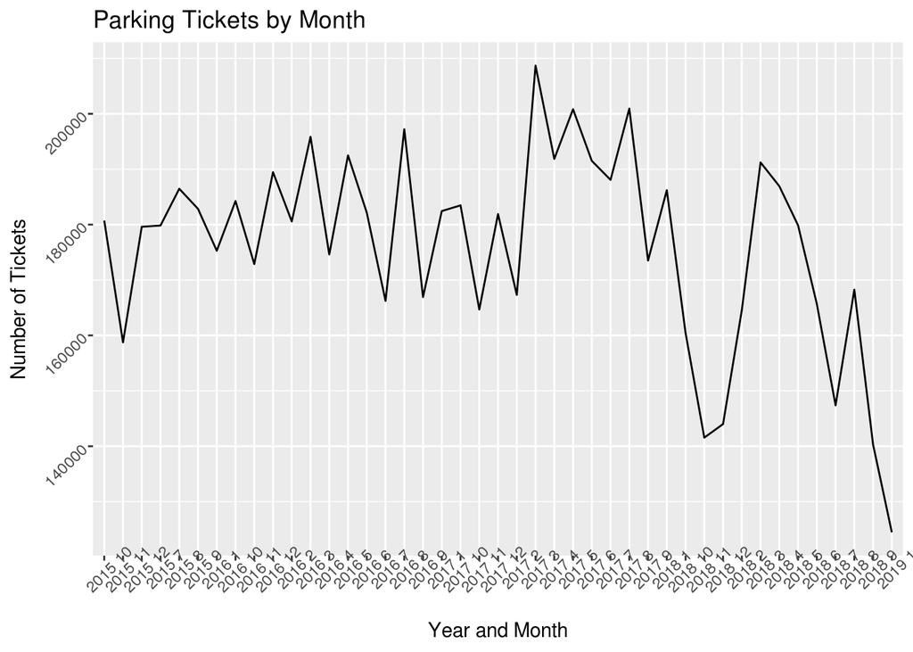

```r
library(ggplot2)

la_sql %>%
  mutate(Issue_Date = paste(Issue_Year, Issue_Month)) %>%
  group_by(Issue_Date) %>%
  filter(is.na(Issue_Date) == FALSE) %>%
  summarize(n = n()) %>%
  ggplot(aes(x = Issue_Date, y = n, group = 1)) +
    geom_line() +
      ggtitle("Parking Tickets by Month") + labs(x = "Year and Month",
                                             y = "Number of Tickets") +
  theme(axis.text.x = element_text(angle=45),
          axis.text.y = element_text(angle=45))
```